# Heart Disease - A Primary Study

Oindrila Sen

Feb - 2019

## Introduction

Using the 14 attributes from the Cleveland Hospital Heart Disease Database, let’s try to analyze how each of those features is contributing to the disease. Then based on those features, let’s build a classifier to determine if a patient is likely to have heart disease or not.

**The Attributes:**  
1. age  
2. sex  
3. chest pain type (4 values)  
4. resting blood pressure  
5. serum cholestoral in mg/dl  
6. fasting blood sugar > 120 mg/dl  
7. resting electrocardiographic results (values 0,1,2)  
8. maximum heart rate achieved  
9. exercise induced angina  
10. oldpeak = ST depression induced by exercise relative to rest  
11. the slope of the peak exercise ST segment  
12. number of major vessels (0-3) colored by flourosopy  
13. thal: 3 = normal; 6 = fixed defect; 7 = reversable defect  
14. target (0, 1 )

## Load Data

```r
######################################
# 1. Load Data
######################################
# Set Working Directory
setwd("/Users/oindrilasen/WORK_AREA/Data Science/Kaggle/HeartDiseaseUCI")
# Read train.csv data file
disease<-read.csv("heart.csv",
                  header = TRUE
                  ,na.strings = "",
                  stringsAsFactors = FALSE
)
# Let's take a look at the data
dim(disease)
```

```
## [1] 303  14
```

```r
glimpse(disease)
```

```
## Observations: 303
## Variables: 14
## $ age      <int> 63, 37, 41, 56, 57, 57, 56, 44, 52, 57, 54, 48, 49, 6...
## $ sex      <int> 1, 1, 0, 1, 0, 1, 0, 1, 1, 1, 1, 0, 1, 1, 0, 0, 0, 0,...
## $ cp       <int> 3, 2, 1, 1, 0, 0, 1, 1, 2, 2, 0, 2, 1, 3, 3, 2, 2, 3,...
## $ trestbps <int> 145, 130, 130, 120, 120, 140, 140, 120, 172, 150, 140...
## $ chol     <int> 233, 250, 204, 236, 354, 192, 294, 263, 199, 168, 239...
## $ fbs      <int> 1, 0, 0, 0, 0, 0, 0, 0, 1, 0, 0, 0, 0, 0, 1, 0, 0, 0,...
## $ restecg  <int> 0, 1, 0, 1, 1, 1, 0, 1, 1, 1, 1, 1, 1, 0, 0, 1, 1, 1,...
## $ thalach  <int> 150, 187, 172, 178, 163, 148, 153, 173, 162, 174, 160...
## $ exang    <int> 0, 0, 0, 0, 1, 0, 0, 0, 0, 0, 0, 0, 0, 1, 0, 0, 0, 0,...
## $ oldpeak  <dbl> 2.3, 3.5, 1.4, 0.8, 0.6, 0.4, 1.3, 0.0, 0.5, 1.6, 1.2...
## $ slope    <int> 0, 0, 2, 2, 2, 1, 1, 2, 2, 2, 2, 2, 2, 1, 2, 1, 2, 0,...
## $ ca       <int> 0, 0, 0, 0, 0, 0, 0, 0, 0, 0, 0, 0, 0, 0, 0, 0, 0, 0,...
## $ thal     <int> 1, 2, 2, 2, 2, 1, 2, 3, 3, 2, 2, 2, 2, 2, 2, 2, 2, 2,...
## $ target   <int> 1, 1, 1, 1, 1, 1, 1, 1, 1, 1, 1, 1, 1, 1, 1, 1, 1, 1,...
```

There are 303 records and 14 features. Now, let’s explore each of the featues a liitle more and clean the data wherever required.

## Data Cleaning

Let’s check first if there are any NULL values for any of the featues.

```r
# 1. Check for NA values
na_count <- sort(sapply(disease, function(x) sum(is.na(x))),
                 decreasing = TRUE)
na_count
```

```
##      age      sex       cp trestbps     chol      fbs  restecg  thalach
##        0        0        0        0        0        0        0        0
##    exang  oldpeak    slope       ca     thal   target
##        0        0        0        0        0        0
```

No, there is no NULL value. The data is already cleaned up.  
Now, let’s check each feature individually.

```r
# 2. Check the different featutes
#age
summary(disease$age)
```

```
##    Min. 1st Qu.  Median    Mean 3rd Qu.    Max.
##   29.00   47.50   55.00   54.37   61.00   77.00
```

In the dataset, age varies from 29 to 77. Well, that’s a good range of values.  
The Sex of the person is represented as 1 =Male and 0 = Female. That is a little confusing. Let’s convert the data into “M” and “F”.

```r
# sex
unique(disease$sex)
```

```
## [1] 1 0
```

```r
#Modify Sex Values to M and F
disease$sex <- ifelse(disease$sex == 1, "M","F")
table(disease$sex)
```

```
##
##   F   M
##  96 207
```

```r
# cp - chest pain type
table(disease$cp)
```

```
##
##   0   1   2   3
## 143  50  87  23
```

```r
#trestbps
summary(disease$trestbps)
```

```
##    Min. 1st Qu.  Median    Mean 3rd Qu.    Max.
##    94.0   120.0   130.0   131.6   140.0   200.0
```

```r
#chol
summary(disease$chol)
```

```
##    Min. 1st Qu.  Median    Mean 3rd Qu.    Max.
##   126.0   211.0   240.0   246.3   274.5   564.0
```

```r
# fbs = (fasting blood sugar > 120 mg/dl) 1 = true; 0 = false)
table(disease$fbs)
```

```
##
##   0   1
## 258  45
```

```r
# restecg(resting electrocardiographic results)
table(disease$restecg)
```

```
##
##   0   1   2
## 147 152   4
```

```r
#thalach
summary(disease$thalach)
```

```
##    Min. 1st Qu.  Median    Mean 3rd Qu.    Max.
##    71.0   133.5   153.0   149.6   166.0   202.0
```

```r
#exang
table(disease$exang)
```

```
##
##   0   1
## 204  99
```

```r
#oldpeak
summary(disease$oldpeak)
```

```
##    Min. 1st Qu.  Median    Mean 3rd Qu.    Max.
##    0.00    0.00    0.80    1.04    1.60    6.20
```

```r
#slope
table(disease$slope)
```

```
##
##   0   1   2
##  21 140 142
```

```r
#ca
summary(disease$ca)
```

```
##    Min. 1st Qu.  Median    Mean 3rd Qu.    Max.
##  0.0000  0.0000  0.0000  0.7294  1.0000  4.0000
```

```r
#thal
summary(disease$thal)
```

```
##    Min. 1st Qu.  Median    Mean 3rd Qu.    Max.
##   0.000   2.000   2.000   2.314   3.000   3.000
```

```r
#target
table(disease$target)
```

```
##
##   0   1
## 138 165
```

Let’s convert the variables with limited set of values to Factors.

```r
# 3. Convert to Factors
disease$target <- as.factor(disease$target)
disease$sex <- as.factor(disease$sex)
disease$cp <- as.factor(disease$cp)
disease$fbs <- as.factor(disease$fbs)
disease$restecg <- as.factor(disease$restecg)
disease$exang <- as.factor(disease$exang)
disease$slope <- as.factor(disease$slope)

glimpse(disease)
```

```
## Observations: 303
## Variables: 14
## $ age      <int> 63, 37, 41, 56, 57, 57, 56, 44, 52, 57, 54, 48, 49, 6...
## $ sex      <fctr> M, M, F, M, F, M, F, M, M, M, M, F, M, M, F, F, F, F...
## $ cp       <fctr> 3, 2, 1, 1, 0, 0, 1, 1, 2, 2, 0, 2, 1, 3, 3, 2, 2, 3...
## $ trestbps <int> 145, 130, 130, 120, 120, 140, 140, 120, 172, 150, 140...
## $ chol     <int> 233, 250, 204, 236, 354, 192, 294, 263, 199, 168, 239...
## $ fbs      <fctr> 1, 0, 0, 0, 0, 0, 0, 0, 1, 0, 0, 0, 0, 0, 1, 0, 0, 0...
## $ restecg  <fctr> 0, 1, 0, 1, 1, 1, 0, 1, 1, 1, 1, 1, 1, 0, 0, 1, 1, 1...
## $ thalach  <int> 150, 187, 172, 178, 163, 148, 153, 173, 162, 174, 160...
## $ exang    <fctr> 0, 0, 0, 0, 1, 0, 0, 0, 0, 0, 0, 0, 0, 1, 0, 0, 0, 0...
## $ oldpeak  <dbl> 2.3, 3.5, 1.4, 0.8, 0.6, 0.4, 1.3, 0.0, 0.5, 1.6, 1.2...
## $ slope    <fctr> 0, 0, 2, 2, 2, 1, 1, 2, 2, 2, 2, 2, 2, 1, 2, 1, 2, 0...
## $ ca       <int> 0, 0, 0, 0, 0, 0, 0, 0, 0, 0, 0, 0, 0, 0, 0, 0, 0, 0,...
## $ thal     <int> 1, 2, 2, 2, 2, 1, 2, 3, 3, 2, 2, 2, 2, 2, 2, 2, 2, 2,...
## $ target   <fctr> 1, 1, 1, 1, 1, 1, 1, 1, 1, 1, 1, 1, 1, 1, 1, 1, 1, 1...
```

## Exploratory Data Analysis

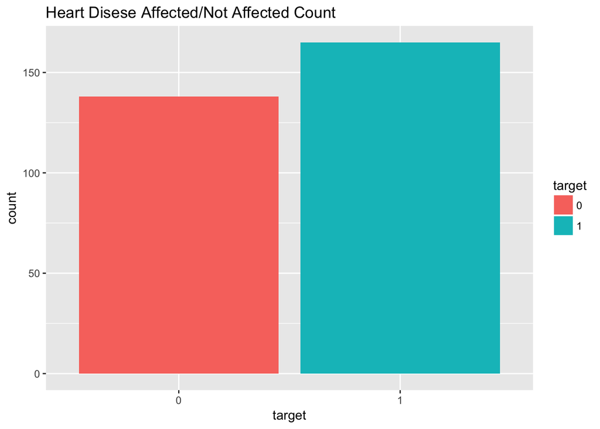

```r
######################################
# 3. Exploratory Data Analysis
######################################
# Target
# (1=yes, 0=no)
ggplot(disease, aes(x = target, fill = target)) +
  geom_bar()+
  ggtitle("Heart Disese Affected/Not Affected Count")
```

In our current dataset, we have more records of people who are Affected by the Heart Disease. I guess, that will help us to analyze better.

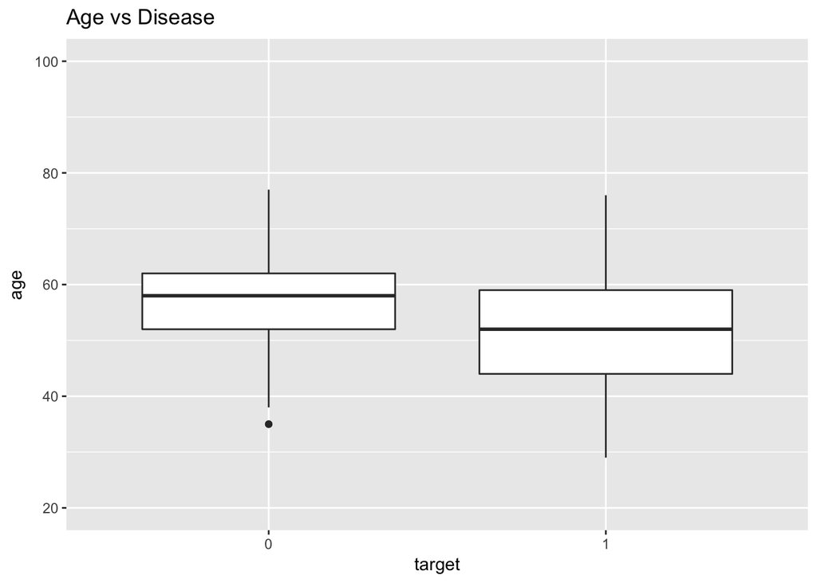

```r
# Age
ggplot(disease, aes(x = target, y = age)) +
  geom_boxplot(na.rm = TRUE) +
  ylim(20, 100)+
  ggtitle("Age vs Disease")
```

As per our general assumption, older people are more prone to a Heart Disease. But our current Dataset tells a different story.

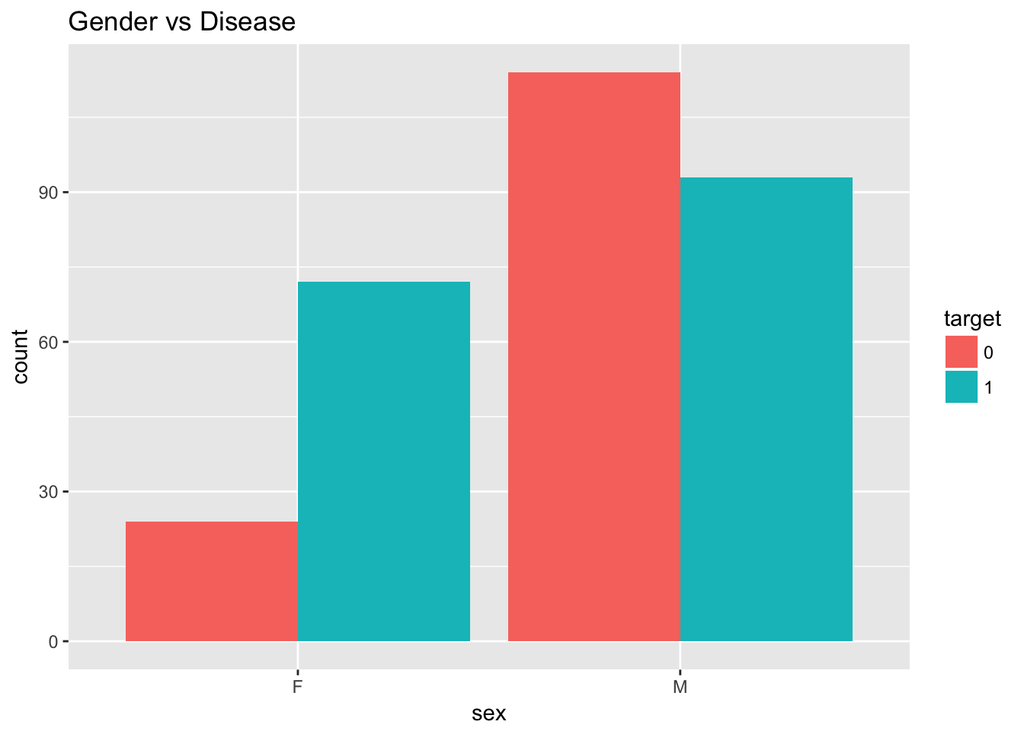

```r
#Sex
ggplot(disease, aes(x = sex, fill = target)) +
  geom_bar(position = "dodge") +
  ggtitle("Gender vs Disease")
```

The Female population in this dataset are more likely to have a heart disease!

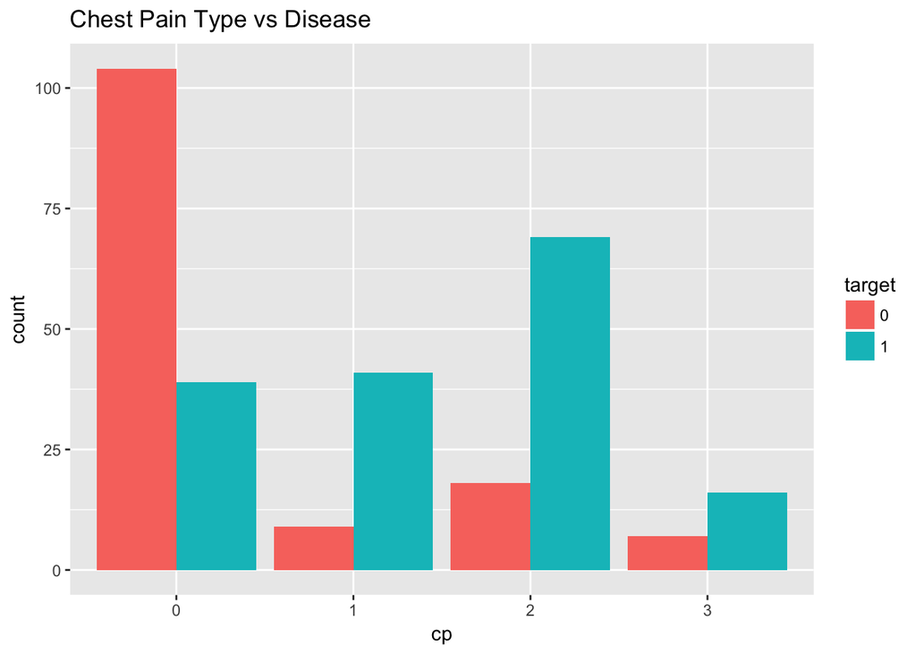

```r
# cp
ggplot(disease, aes(x = cp, fill= target)) +
  geom_bar(position = "dodge")+
  ggtitle("Chest Pain Type vs Disease")
```

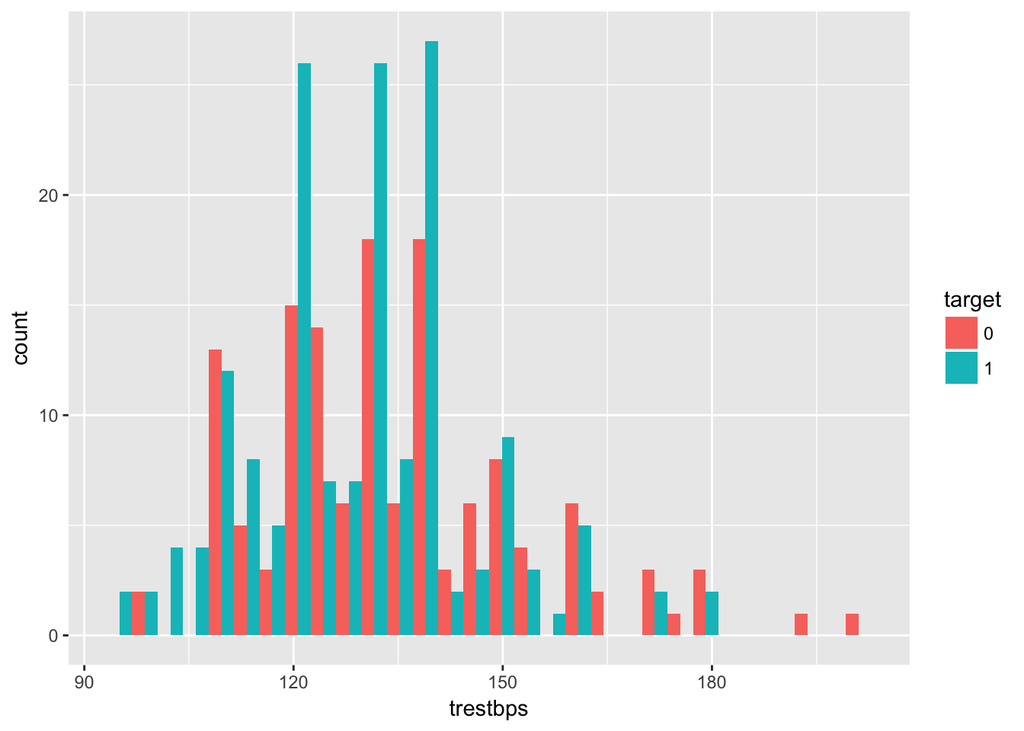

```r
# trestbps
ggplot(disease, aes(x = trestbps,fill = target)) +
  geom_histogram(position = "dodge")
```

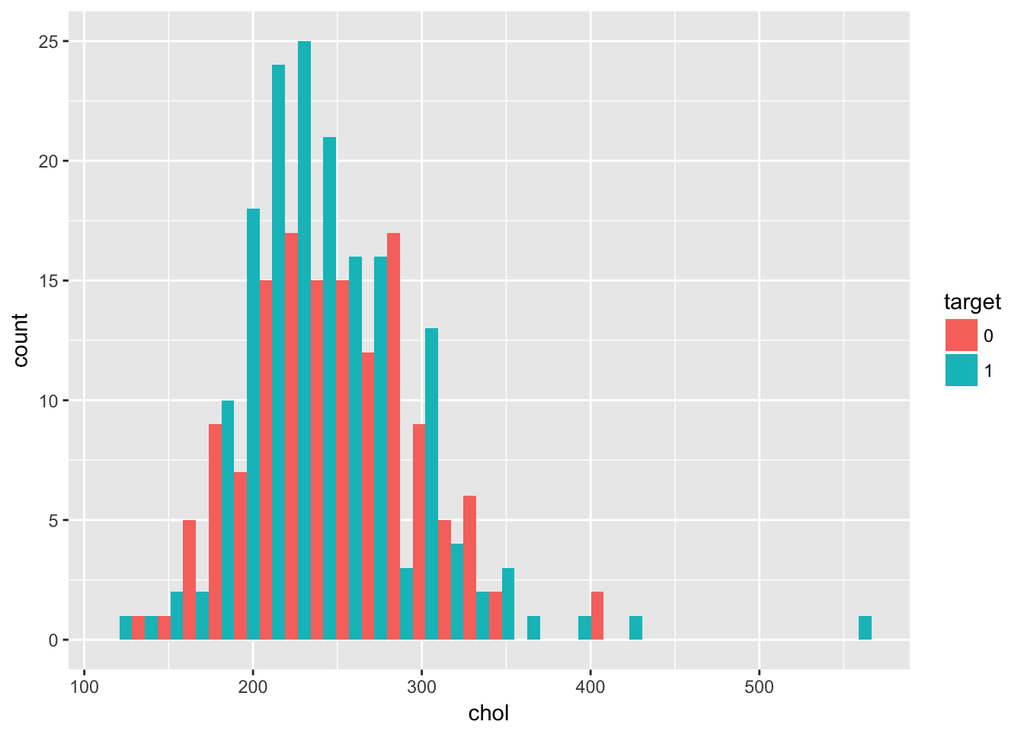

```r
# chol
ggplot(disease, aes(x = chol,fill = target)) +
  geom_histogram(position = "dodge")
```

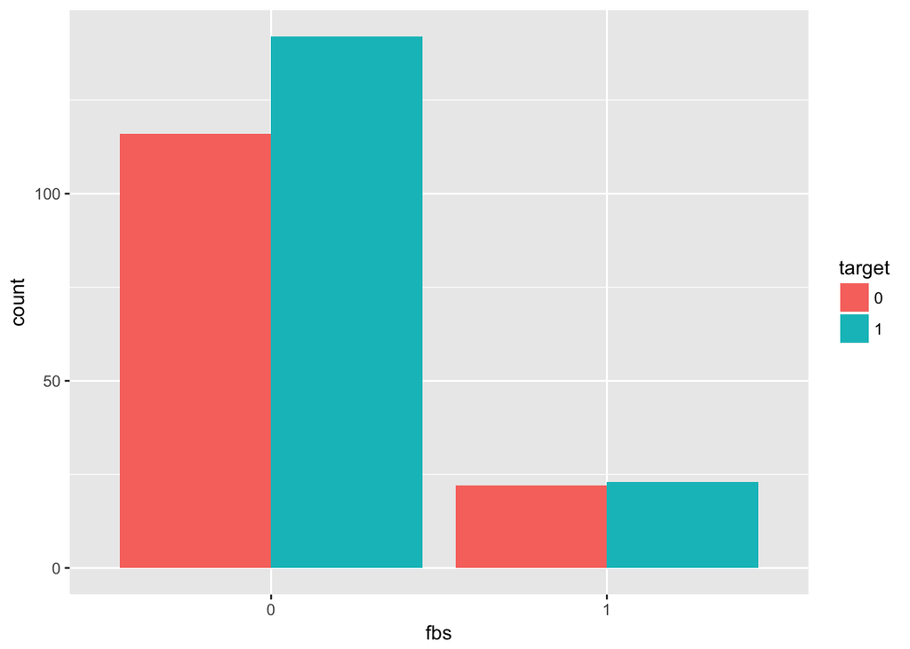

```r
#fbs
#fasting blood sugar > 120 mg/dl) (1 = true; 0 = false)
ggplot(disease, aes(x = fbs, fill= target)) +
  geom_bar(position = "dodge")
```

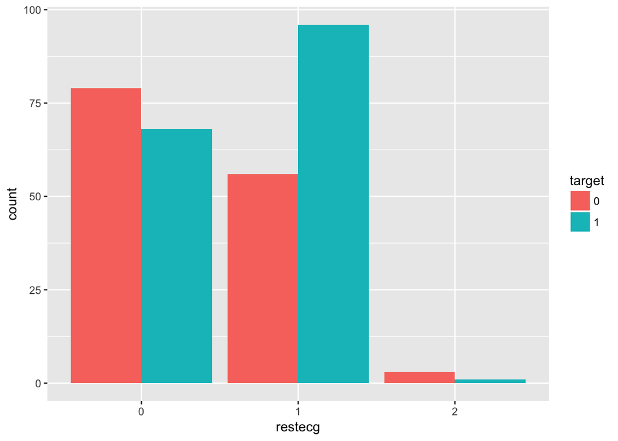

```r
#restecg
ggplot(disease, aes(x = restecg, fill= target)) +
  geom_bar(position = "dodge")
```

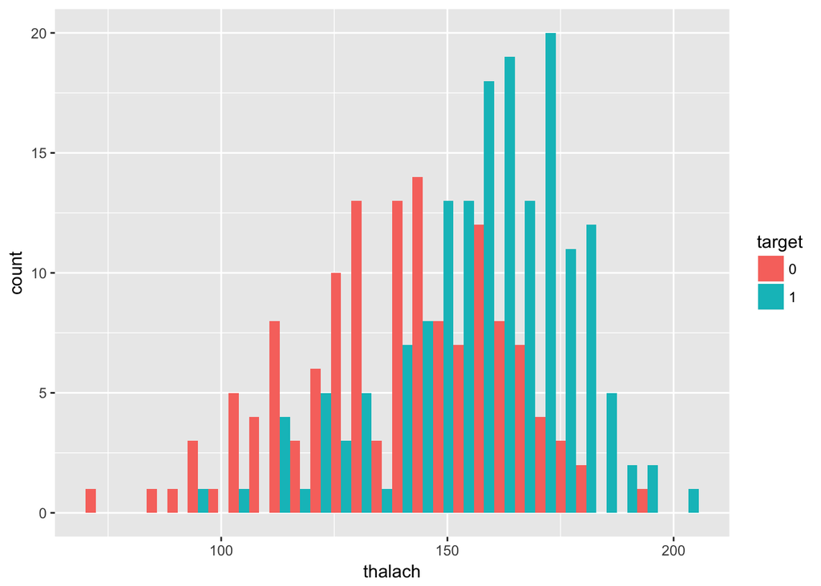

```r
#thalach
ggplot(disease, aes(x = thalach,fill = target)) +
  geom_histogram(position = "dodge")
```

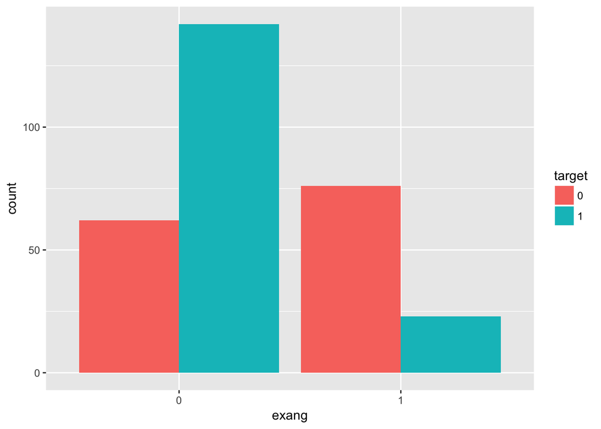

```r
# exang
ggplot(disease, aes(x = exang, fill= target)) +
  geom_bar(position = "dodge")
```

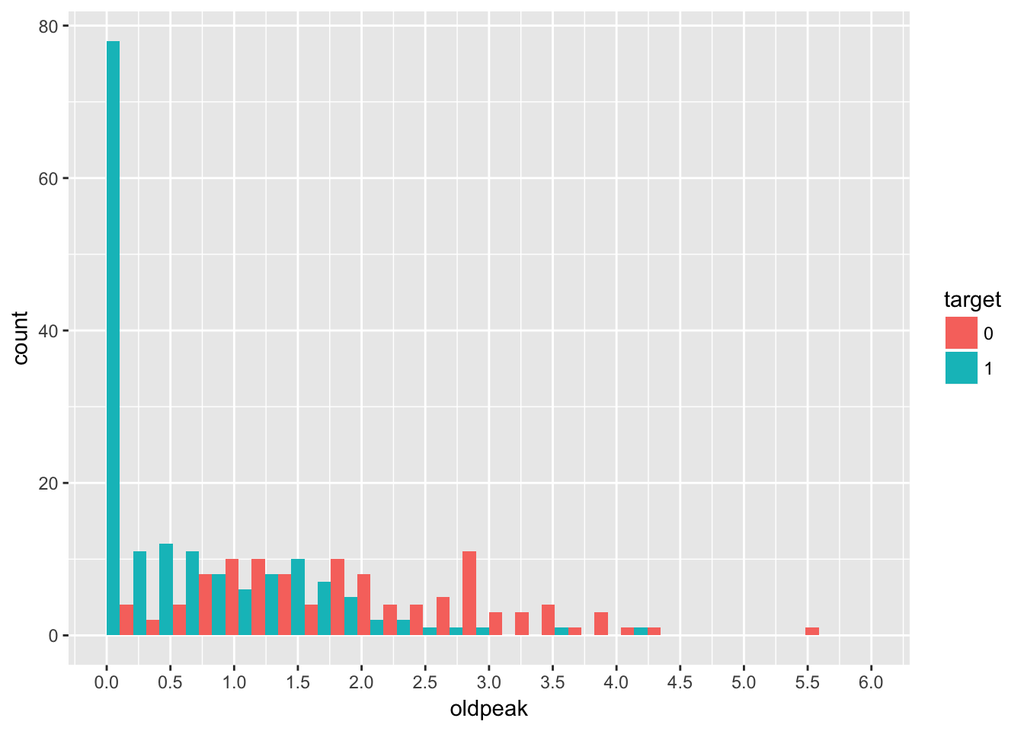

```r
#oldpeak
ggplot(disease, aes(x = oldpeak,fill = target)) +
  geom_histogram(position = "dodge")+
  scale_x_continuous(limits = c(0, 6), breaks = seq(0, 6, 0.50))
```

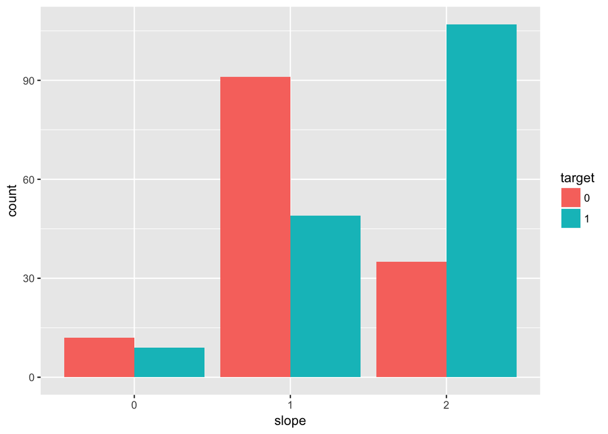

```r
#slope
ggplot(disease, aes(x = slope, fill= target)) +
  geom_bar(position = "dodge")
```

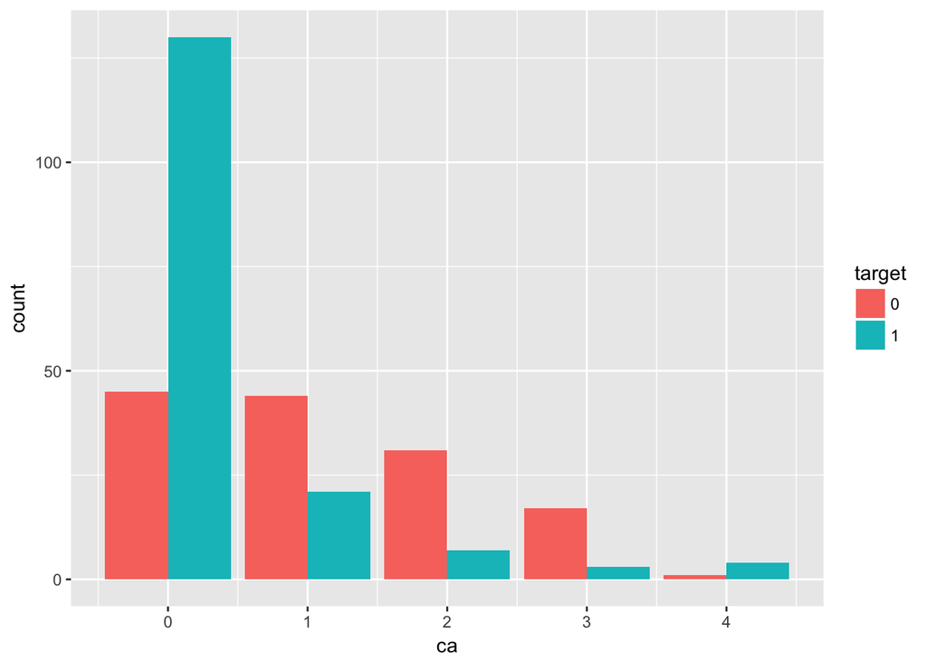

```r
#ca
ggplot(disease, aes(x = ca, fill= target)) +
  geom_bar(position = "dodge")
```

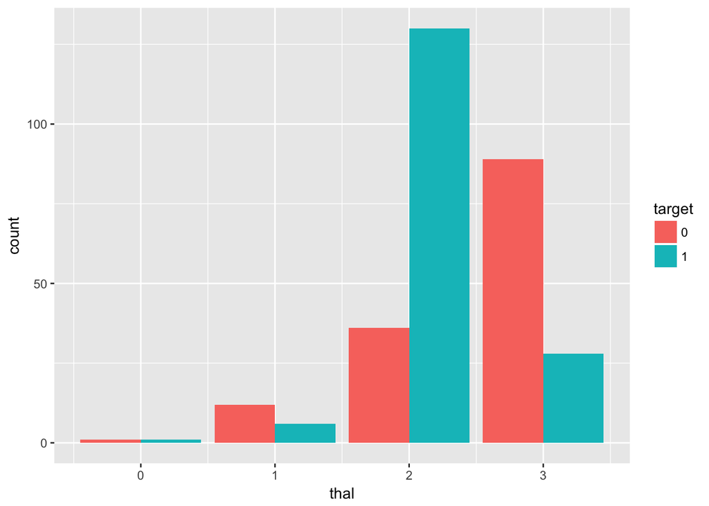

```r
#thal
ggplot(disease, aes(x = thal, fill= target)) +
  geom_bar(position = "dodge")
```

## Create a Simple Model

```r
######################################
# 4. Data Model
######################################
set.seed(150)
#Sample Indexes
indexes = sample(1:nrow(disease), size = 0.2 * nrow(disease))
# Split dataset into training and test set
test_data = disease[indexes, ]
train_data = disease[-indexes, ]

dim(train_data)
```

```
## [1] 243  14
```

```r
dim(test_data)
```

```
## [1] 60 14
```

```r
lg_model <- glm(target ~ .,
                data = train_data,
                family = binomial(link = "logit"))

summary(lg_model)
```

```
##
## Call:
## glm(formula = target ~ ., family = binomial(link = "logit"),
##     data = train_data)
##
## Deviance Residuals:
##     Min       1Q   Median       3Q      Max
## -2.5542  -0.3928   0.1298   0.5133   2.5788
##
## Coefficients:
##              Estimate Std. Error z value Pr(>|z|)
## (Intercept)  6.581395   3.162544   2.081 0.037430 *
## age         -0.000784   0.026642  -0.029 0.976525
## sexM        -1.698467   0.530066  -3.204 0.001354 **
## cp1          0.909476   0.610578   1.490 0.136347
## cp2          2.295391   0.561636   4.087 4.37e-05 ***
## cp3          2.371796   0.739192   3.209 0.001334 **
## trestbps    -0.029896   0.012198  -2.451 0.014247 *
## chol        -0.002595   0.004518  -0.574 0.565731
## fbs1         0.351072   0.670097   0.524 0.600340
## restecg1     0.524144   0.416393   1.259 0.208112
## restecg2    -0.278183   2.433753  -0.114 0.908998
## thalach      0.011139   0.011979   0.930 0.352422
## exang1      -0.916627   0.471640  -1.943 0.051957 .
## oldpeak     -0.543482   0.243373  -2.233 0.025541 *
## slope1      -0.155088   0.886944  -0.175 0.861192
## slope2       1.006840   0.938288   1.073 0.283244
## ca          -0.817754   0.245307  -3.334 0.000857 ***
## thal        -1.070723   0.357847  -2.992 0.002770 **
## ---
## Signif. codes:  0 '***' 0.001 '**' 0.01 '*' 0.05 '.' 0.1 ' ' 1
##
## (Dispersion parameter for binomial family taken to be 1)
##
##     Null deviance: 335.05  on 242  degrees of freedom
## Residual deviance: 161.19  on 225  degrees of freedom
## AIC: 197.19
##
## Number of Fisher Scoring iterations: 6
```

The summary shows that some of the features are not contributing to the Model. Let’s use only those features which seems important.

```r
lg_model_rev <- glm(target ~ sex+ cp + ca + thal + exang + oldpeak,
                    data = train_data,
                    family = binomial(link = "logit"))
summary(lg_model_rev)
```

```
##
## Call:
## glm(formula = target ~ sex + cp + ca + thal + exang + oldpeak,
##     family = binomial(link = "logit"), data = train_data)
##
## Deviance Residuals:
##     Min       1Q   Median       3Q      Max
## -2.5248  -0.4706   0.1951   0.5506   2.3199
##
## Coefficients:
##             Estimate Std. Error z value Pr(>|z|)
## (Intercept)   4.1752     0.8642   4.831 1.36e-06 ***
## sexM         -1.2076     0.4416  -2.735 0.006242 **
## cp1           0.9949     0.5386   1.847 0.064745 .
## cp2           2.2177     0.5066   4.378 1.20e-05 ***
## cp3           1.9610     0.6873   2.853 0.004329 **
## ca           -0.7738     0.2059  -3.759 0.000171 ***
## thal         -1.0201     0.3103  -3.288 0.001010 **
## exang1       -1.1479     0.4248  -2.702 0.006887 **
## oldpeak      -0.8001     0.2134  -3.749 0.000177 ***
## ---
## Signif. codes:  0 '***' 0.001 '**' 0.01 '*' 0.05 '.' 0.1 ' ' 1
##
## (Dispersion parameter for binomial family taken to be 1)
##
##     Null deviance: 335.05  on 242  degrees of freedom
## Residual deviance: 180.05  on 234  degrees of freedom
## AIC: 198.05
##
## Number of Fisher Scoring iterations: 6
```

## Prediction and Check Accuracy of the Model

```r
######################################
# 4. Prediction
######################################
test_data$predicted_target <- predict(lg_model_rev,
                                      test_data,
                                      type =  "response")

summary(test_data$predicted_target )
```

```
##    Min. 1st Qu.  Median    Mean 3rd Qu.    Max.
## 0.00743 0.17610 0.71137 0.55987 0.87238 0.98729
```

```r
test_data$predicted_target  <- round(test_data$predicted_target )

table(test_data$target)
```

```
##
##  0  1
## 27 33
```

```r
table(test_data$predicted_target)
```

```
##
##  0  1
## 24 36
```

```r
# Check Accuracy of the Model
lconfMat <- table(`Actual Class` = test_data$target,`Predicted Class` =test_data$predicted_target)
laccuracy <- sum(diag(lconfMat))/sum(lconfMat)
laccuracy
```

```
## [1] 0.85
```

```r
# Test prediction at a random record
# Generate a Random Number
dim(test_data)
```

```
## [1] 60 15
```

```r
randomNum <- sample(1:60, 1)
test_data$target[randomNum]
```

```
## [1] 0
## Levels: 0 1
```

```r
test_data$predicted_target[randomNum]
```

```
## [1] 0
```

The accuracy of the basic Logistic Regression Model is 85% which is not so bad!